# Работа на сервере - второй этап внешнего курса

## Почему ответ верен: Открываем две вкладки в терменале в одной из них запускаем процесс и приостанавливаем его

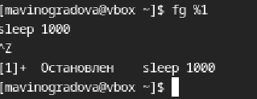

Пишем в первом терменале

## Переключаемся на вторую вкладку и набираем fg

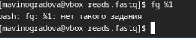

## Ознакамливаемся с девятнадцатым вопросом

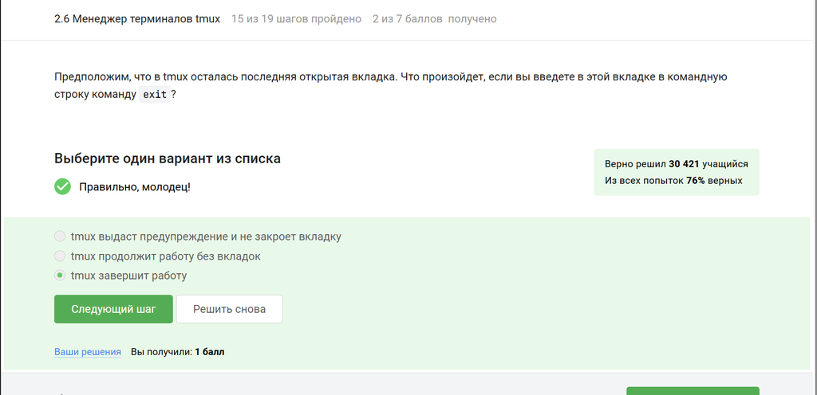

Смотрим текст вопроса

## Почему ответ верен: Открываем tmux и вводим в открывшемся терменале команду exit

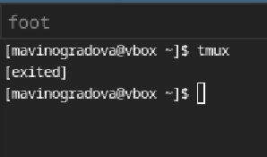

## Ознакамливаемся с двадцатым вопросом

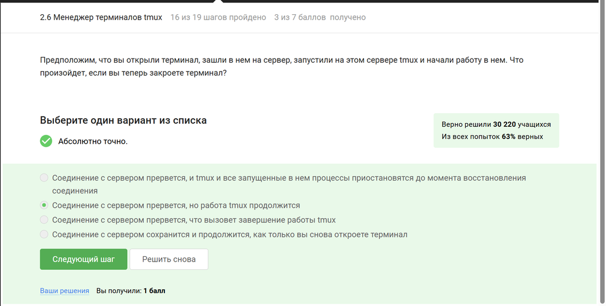

Смотрим текст вопроса

## Почему ответ верен:

- tmux (терминальный мультиплексор) работает независимо от окна терминала.
- Все процессы внутри tmux выполняются на сервере, а не в локальном терминале.
- Даже если закрыть терминал, сессия tmux останется активной.

Ознакамливаемся с двадцать первым вопросом

## Ознакамливаемся с двадцать первым вопросом

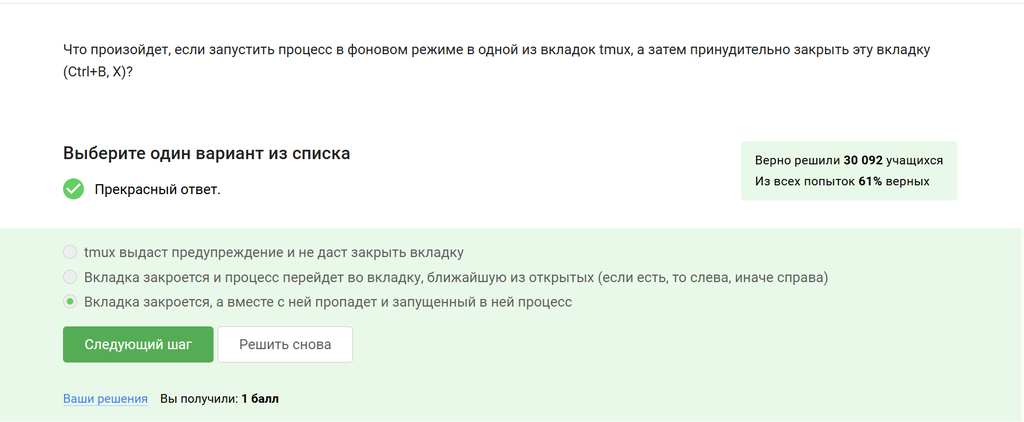

Смотрим текст вопроса

## Почему ответ верен:

- В tmux каждый процесс привязан к своей вкладке (окну).
- Принудительное закрытие (Ctrl+B, X) убивает всё содержимое вкладки, включая фоновые процессы.

## Ознакамливаемся с двадцать вторым вопросом

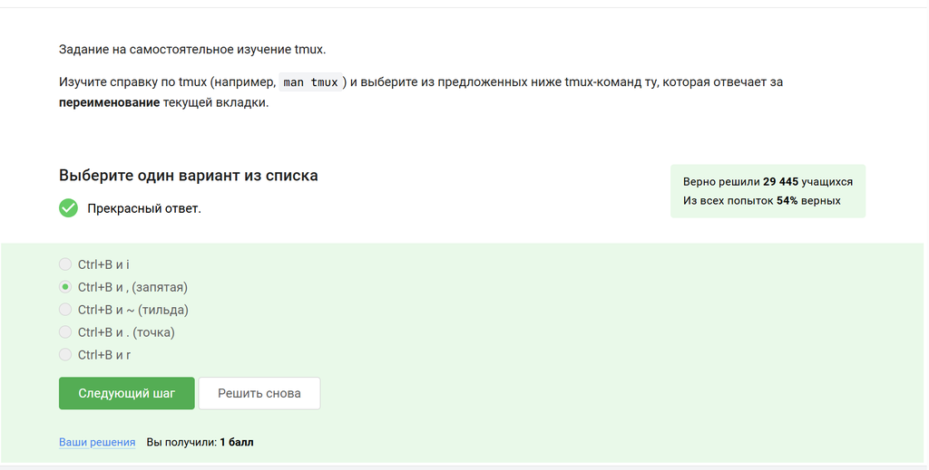

Смотрим текст вопроса

## Почему ответ верен: Смотрим справку по tmux

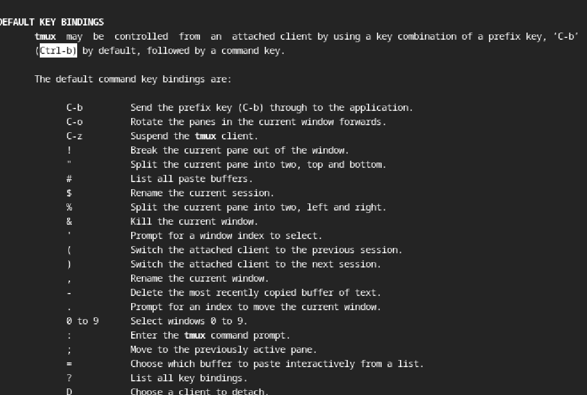

Выполняем задание

## Ознакамливаемся с двадцать третьим вопросом

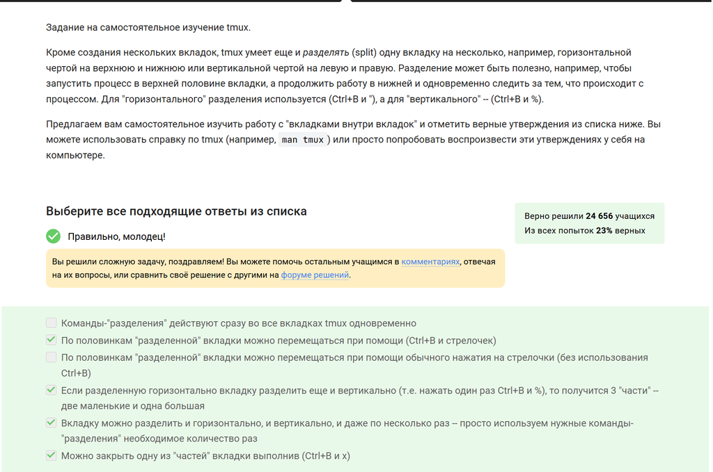

Смотрим текст вопроса

## Почему ответ верен: Заходим в tmux и пробуем делить экран и перемещаться по ним

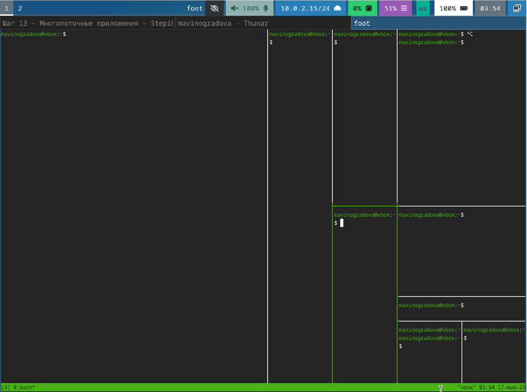

Выполняем задание

# Выводы

Освоив работу на удаленном сервере, я научилась подключаться через SSH, запускать биоинформатические программы и управлять процессами. Теперь могу передавать данные между сервером и локальным компьютером, контролировать ресурсы и оптимизировать работу с большими файлами. Эти навыки позволяют эффективно использовать удаленные мощности для анализа данных.